# GDP, Population and Life Expectancy

by Ethan Floate, 04-07-2020

Richer countries can afford to invest more on healthcare, on work and road safety, and other measures that reduce mortality. On the other hand, richer countries may have less healthy lifestyles. Is there any relation between the wealth of a country and the life expectancy of its inhabitants?

The following analysis checks whether there is any correlation between the total gross domestic product (GDP) of a country in 2013 and the life expectancy of people born in that country in 2013.

## Getting the data

```python
import warnings
warnings.simplefilter('ignore', FutureWarning)

from pandas import *

YEAR = 2013
GDP_INDICATOR = 'NY.GDP.MKTP.CD'
gdpReset = read_csv('WB GDP 2013.csv')

POP_INDICATOR = 'SP.POP.TOTL'
popReset = read_csv('WB POP 2013.csv')

LE_INDICATOR = 'SP.DYN.LE00.IN'
leReset = read_csv('WB LE 2013.csv')
leReset.head()
```

|  | country | year | SP.DYN.LE00.IN |
| --- | --- | --- | --- |
| 0 | Arab World | 2013 | 70.631305 |
| 1 | Caribbean small states | 2013 | 71.901964 |
| 2 | Central Europe and the Baltics | 2013 | 76.127583 |
| 3 | East Asia & Pacific (all income levels) | 2013 | 74.604619 |
| 4 | East Asia & Pacific (developing only) | 2013 | 73.657617 |

## Cleaning the data

Inspecting the data with `head()` and `tail()` shows that:

1. the first 34 rows are aggregated data, for the Arab World, the Caribbean small states, and other country groups used by the World Bank;
- GDP and life expectancy values are missing for some countries.

The data is therefore cleaned by:

1. removing the first 34 rows;
- removing rows with unavailable values.

```python
gdpCountries = gdpReset[34:].dropna()
popCountries = popReset[34:].dropna()
leCountries = leReset[34:].dropna()
```

## Transforming the data

The World Bank reports GDP in US dollars and cents. To make the data easier to read, the GDP is converted to millions of British pounds (the author's local currency) with the following auxiliary functions, using the average 2013 dollar-to-pound conversion rate provided by http://www.ukforex.co.uk/forex-tools/historical-rate-tools/yearly-average-rates.

```python
def roundToMillions (value):
    return round(value / 1000000)

def usdToGBP (usd):
    return usd / 1.564768

GDP = 'GDP (£m)'
gdpCountries[GDP] = gdpCountries[GDP_INDICATOR].apply(usdToGBP).apply(roundToMillions)
gdpCountries.head()
```

|  | country | year | NY.GDP.MKTP.CD | GDP (£m) |
| --- | --- | --- | --- | --- |
| 34 | Afghanistan | 2013 | 2.045894e+10 | 13075 |
| 35 | Albania | 2013 | 1.278103e+10 | 8168 |
| 36 | Algeria | 2013 | 2.097035e+11 | 134016 |
| 38 | Andorra | 2013 | 3.249101e+09 | 2076 |
| 39 | Angola | 2013 | 1.383568e+11 | 88420 |

The unnecessary columns can be dropped.

```python
COUNTRY = 'country'
headings = [COUNTRY, GDP]
gdpClean = gdpCountries[headings]
gdpClean.head()
```

|  | country | GDP (£m) |
| --- | --- | --- |
| 34 | Afghanistan | 13075 |
| 35 | Albania | 8168 |
| 36 | Algeria | 134016 |
| 38 | Andorra | 2076 |
| 39 | Angola | 88420 |

```python
popCountries.head()
```

|  | country | year | SP.POP.TOTL |
| --- | --- | --- | --- |
| 34 | Afghanistan | 2013 | 30682500.0 |
| 35 | Albania | 2013 | 2897366.0 |
| 36 | Algeria | 2013 | 38186135.0 |
| 37 | American Samoa | 2013 | 55302.0 |
| 38 | Andorra | 2013 | 75902.0 |

The World Bank reports the population with as its actual figure. To make this easier to read, we will divide it by 1000

```python
POP = 'Population (1000s)'
popCountries[POP] = (popCountries[POP_INDICATOR] / 1000).astype('int64')
popHeadings = [COUNTRY,POP]
popClean = popCountries[popHeadings]
popClean.head()
```

|  | country | Population (1000s) |
| --- | --- | --- |
| 34 | Afghanistan | 30682 |
| 35 | Albania | 2897 |
| 36 | Algeria | 38186 |
| 37 | American Samoa | 55 |
| 38 | Andorra | 75 |

```python
LE = 'Life Expectancy'
leCountries[LE] = leCountries[LE_INDICATOR]
leHeadings = [COUNTRY,LE]
leClean = leCountries[leHeadings]
leClean.head()
```

|  | country | Life Expectancy |
| --- | --- | --- |
| 34 | Afghanistan | 60.028268 |
| 35 | Albania | 77.537244 |
| 36 | Algeria | 74.568951 |
| 39 | Angola | 51.866171 |
| 40 | Antigua and Barbuda | 75.778659 |

## Combining the data

The tables are combined through an inner join on the common 'country' column.

```python
gdpVsPop = merge(gdpClean, popClean, on=COUNTRY, how='inner')
gdpVsPopVsLe = gdpVsPop.merge(leClean, on=COUNTRY, how='inner')
gdpVsPopVsLe.head()
```

|  | country | GDP (£m) | Population (1000s) | Life Expectancy |
| --- | --- | --- | --- | --- |
| 0 | Afghanistan | 13075 | 30682 | 60.028268 |
| 1 | Albania | 8168 | 2897 | 77.537244 |
| 2 | Algeria | 134016 | 38186 | 74.568951 |
| 3 | Angola | 88420 | 23448 | 51.866171 |
| 4 | Antigua and Barbuda | 767 | 89 | 75.778659 |

## Calculating the correlation

To measure if the life expectancy and the GDP grow together, the Spearman rank correlation coefficient is used. It is a number from -1 (perfect inverse rank correlation: if one indicator increases, the other decreases) to 1 (perfect direct rank correlation: if one indicator increases, so does the other), with 0 meaning there is no rank correlation. A perfect correlation doesn't imply any cause-effect relation between the two indicators. A p-value below 0.05 means the correlation is statistically significant.

```python
from scipy.stats import spearmanr

gdpColumn = gdpVsPopVsLe[GDP]
lifeColumn = gdpVsPopVsLe[LE]
(correlation, pValue) = spearmanr(gdpColumn, lifeColumn)
print('The correlation is', correlation)
if pValue < 0.05:
    print('It is statistically significant.')
else:
    print('It is not statistically significant.')
```

```
The correlation is 0.5077223110380622
It is statistically significant.
```

The value shows a direct correlation, i.e. richer countries tend to have longer life expectancy, but it is not very strong.

```python
popColumn = gdpVsPopVsLe[POP]
(correlation, pValue) = spearmanr(gdpColumn, popColumn)
print('The correlation is', correlation)
if pValue < 0.05:
    print('It is statistically significant.')
else:
    print('It is not statistically significant.')
```

```
The correlation is 0.7085762559992608
It is statistically significant.
```

Another direct correlation between population and GDP, stronger than previous correlation

```python
(correlation, pValue) = spearmanr(lifeColumn, popColumn)
print('The correlation is', correlation)
if pValue < 0.05:
    print('It is statistically significant.')
else:
    print('It is not statistically significant.')
```

```
The correlation is -0.07937578034453767
It is not statistically significant.
```

However, there is no correlation between population and life expectancy!

## Showing the data

Measures of correlation can be misleading, so it is best to see the overall picture with a scatterplot. The X axis uses a logarithmic scale to better display the vast range of GDP values, from a few million to several billion (million of million) pounds.

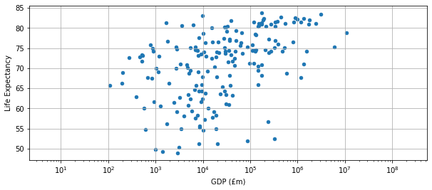

```python
%matplotlib inline
gdpVsPopVsLe.plot(x=GDP, y=LE, kind='scatter', grid=True, logx=True, figsize=(10, 4))
```

The plot shows there is no clear correlation: there are rich countries with low life expectancy, poor countries with high expectancy, and countries with around 10 thousand (10<sup>4</sup>) million pounds GDP have almost the full range of values, from below 50 to over 80 years. Towards the lower and higher end of GDP, the variation diminishes. Above 40 thousand million pounds of GDP (3rd tick mark to the right of 10<sup>4</sup>), most countries have an expectancy of 70 years or more, whilst below that threshold most countries' life expectancy is below 70 years.

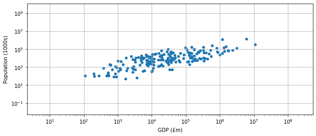

```python
gdpVsPopVsLe.plot(x=GDP, y=POP, kind='scatter', grid=True, logx=True, logy=True, figsize=(10, 4))
```

However, this plot does show a clearer correlation. Rich countries tend to have a higher population than poor ones. As well as this, any country below 20 thousand million pounds of GDP has a population of less than 100 million. If we think about it, the correlation between population and GDP is certainly not a revelation, but a logical certainty. As GDP is measure of the health and **size** of an economy, a larger population would naturally lead to a larger GDP. The correlation is in fact a natural attribute of the measurement GDP.

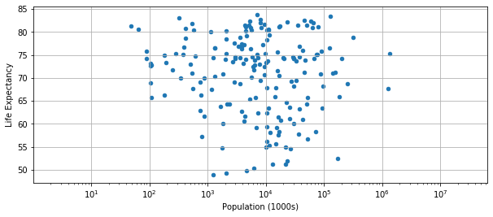

```python
gdpVsPopVsLe.plot(x=POP, y=LE, kind='scatter', grid=True, logx=True, figsize=(10, 4))
```

This graph also shows no correlation at all. Countries that have a population of over 100 million have a life expecancy range of around 52 to 84. A gap of over 30 years! And countries that have a population between a million and 10 million have a life expectancy range of around 35 years.

Comparing the 10 poorest countries and the 10 countries with the lowest life expectancy shows that total GDP is a rather crude measure. The population size should be taken into account for a more precise definiton of what 'poor' and 'rich' means. Furthermore, looking at the countries below, droughts and internal conflicts may also play a role in life expectancy.

```python
# the 10 countries with lowest GDP
gdpVsPopVsLe.sort_values(GDP).head(10)
```

|  | country | GDP (£m) | Population (1000s) | Life Expectancy |
| --- | --- | --- | --- | --- |
| 87 | Kiribati | 108 | 108 | 65.766585 |
| 141 | Sao Tome and Principe | 195 | 182 | 66.259512 |
| 111 | Micronesia, Fed. Sts. | 202 | 103 | 68.973390 |
| 168 | Tonga | 277 | 105 | 72.640341 |
| 37 | Comoros | 383 | 751 | 62.932171 |
| 157 | St. Vincent and the Grenadines | 461 | 109 | 72.810878 |
| 140 | Samoa | 509 | 190 | 73.250390 |
| 180 | Vanuatu | 512 | 253 | 71.669244 |
| 65 | Grenada | 538 | 105 | 73.193561 |
| 60 | Gambia, The | 578 | 1866 | 59.999268 |

```python
# the 10 countries with lowest life expectancy
gdpVsPopVsLe.sort_values(LE).head(10)
```

|  | country | GDP (£m) | Population (1000s) | Life Expectancy |
| --- | --- | --- | --- | --- |
| 160 | Swaziland | 2916 | 1250 | 48.937927 |
| 95 | Lesotho | 1418 | 2083 | 49.331463 |
| 32 | Central African Republic | 983 | 4710 | 49.879878 |
| 146 | Sierra Leone | 3092 | 6178 | 50.363122 |
| 33 | Chad | 8276 | 13145 | 51.191488 |
| 41 | Cote d'Ivoire | 19998 | 21622 | 51.208463 |
| 3 | Angola | 88420 | 23448 | 51.866171 |
| 124 | Nigeria | 329100 | 172816 | 52.442146 |
| 116 | Mozambique | 10237 | 26467 | 54.641512 |
| 68 | Guinea-Bissau | 605 | 1757 | 54.838415 |

## Conclusions

To sum up, there is no strong correlation between a country's wealth and the life expectancy of its inhabitants: there is often a wide variation of life expectancy for countries with similar GDP, countries with the lowest life expectancy are not the poorest countries, and countries with the highest expectancy are not the richest countries. Nevertheless there is some relationship, because the vast majority of countries with a life expectancy below 70 years is on the left half of the scatterplot.

Using the NY.GDP.PCAP.PP.CD indicator, GDP per capita in current 'international dollars', would make for a better like-for-like comparison between countries, because it would take population and purchasing power into account. Using more specific data, like expediture on health, could also lead to a better analysis.